# Intro to DS - PCA / PCR

Alexander Thiersch

2022-04-21

```r
#Load Relevant Libraries
library(readr)
library(corrplot)
library(kableExtra)
library(shiny)
```

# USDA Nutrient Dataset

This data was from USDA National Nutrient dataset, pre-processed by @craigkelly from data.world.

## Preparation

### Question 1

**Import the dataset**  
Import the dataset into R. There should be 45 variables. Take a quick look at the data. Just str, head, and tail will do for now.

Dataset Imported.

```r
USDANationalNutrient <- read_csv("/Users/akthiersch/Desktop/Datasets/USDANationalNutrient.csv")

#str(USDANationalNutrient)
#xkabledply(head(USDANationalNutrient))
#xkabledply(tail(USDANationalNutrient))
```

### Question 2

**Drop the first 7 variables**  
Save the rest as a dataframe, and call it `nndf1`.

Dataset has been renamed to `nndf1`.

```r
nndf1=subset(USDANationalNutrient, select=-c(1,2,3,4,5,6,7))

#head(nndf1)
#str(nndf1)
```

## OLS full model

### Question 3

**Issue with full OLS models**  
All the variables are now numerical. Let us build a quick model (full model) to predict `Energy_kcal`, and another full model to predict `VitB12_mcg`. (No fancy output is required.) Vegetarian diet can often be low on B12, which makes one get tired easier. Having a model could be useful. What are the NAs for the coefficients mean? (Try google.)

NA values for coefficients occur because the estimate itself is not estimable. This can happen for multiple reasons including exact collinearity and low observations to estimate the variable,

```r
engkcal_model1<-lm(Energy_kcal~.,data=nndf1)
summary(engkcal_model1)

vitB12_model2<-lm(VitB12_mcg~.,data=nndf1)
summary(vitB12_model2)
```

### Question 4

**Fix duplicate/collinear variables**  
You probably realize where the problem comes from. Alright then, let us

- only keep the first 23 columns,
- standardize all the variables, and
- the save the resulting dataframe as `nndf`

Obtain a simple correlation matrix for the dataframe. If you use the function `xkabledply()` on the correlation matrix, it will print out a nice scrollable table for html and your console output.

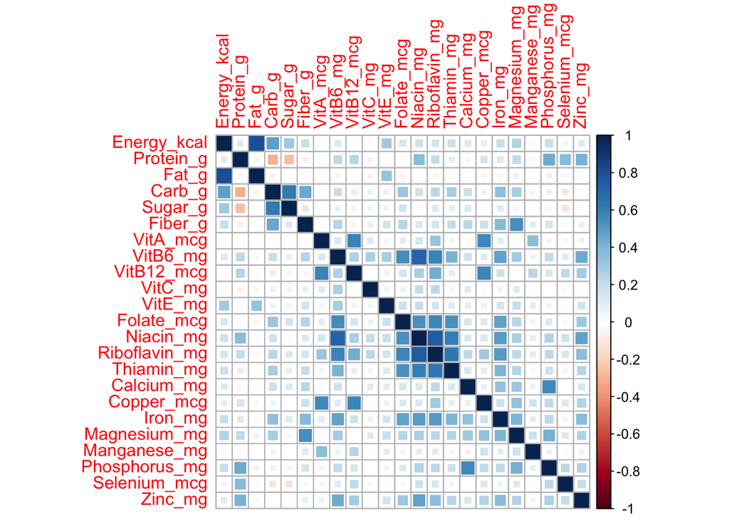

```r
nndf1_mod1 <- subset(nndf1, select = c(1:23))

nndf<- scale(nndf1_mod1, center=TRUE, scale=TRUE)

nndf_mat<-nndf

M = cor(nndf_mat)
corrplot(M, method = 'square')
```

### Question 5

**VitB12_mcg**  
Build a quick full model again for “VitB12_mcg”. What is the $R^2$ value? Notice that using PCA won’t improve the $R^2$. It will only match it if you use all 22 PC-components (1 target, 22 explanatory variables). However, this can be the baseline number to compare.

The multiple R-squared value is 0.5867.

```r
viB12_model3<-lm(VitB12_mcg~.,data=nndf1_mod1)
summary(viB12_model3)
```

[output not shown]

## PCA

### Question 6

**PCA decomposition**  
Instead of PCR, let us run the PCA on this dataset. The dataframe is already centered and scaled. Use  
`nnpcomp <- prcomp(nndf)` to get the 23 PC-components. For `PC1`, which are the four strongest components it consists of?  
(Ans: Riboflavin_mg at -0.3413, Niacin_mg at -0.3378, and so forth.)  
And which are the four strongest for `PC2`?

The four strongest components in PC1 include Riboflavin_mg at -0.3413, Niacin_mg at -0.3378, VitB6_mg at -0.31566282 and Iron_mg at -0.29985690.

```r
nnpcomp <- prcomp(nndf)
```

### Question 7

**BiPlots**  
Make a biplot between `PC1` and `PC2` like this: `biplot( nnpcomp, c(1,2), scale=0 )`. Continue to plot `PC1` with `PC3` (use `c(1,3)`), `c(1,4)`, `c(1,5)`, and `c(1,6)`. Also make biplots for `c(2,3)`, `c(3,4)`, `c(4,5)`, `c(5,6)`.

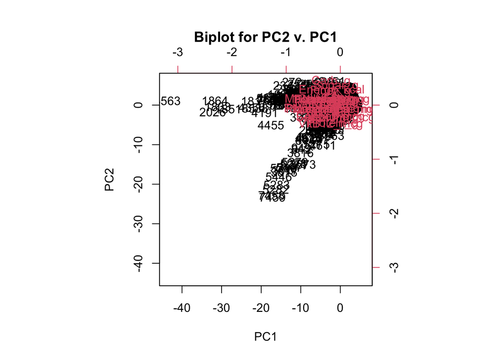

```r
biplot(nnpcomp, c(1,2), scale=0, main='Biplot for PC2 v. PC1')
```

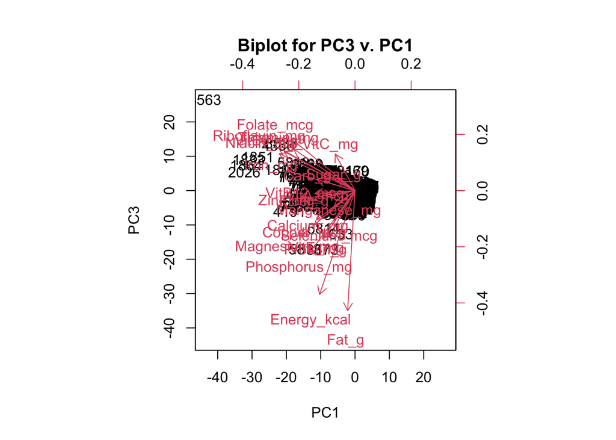

```r
biplot(nnpcomp, c(1,3), scale=0, main='Biplot for PC3 v. PC1')
```

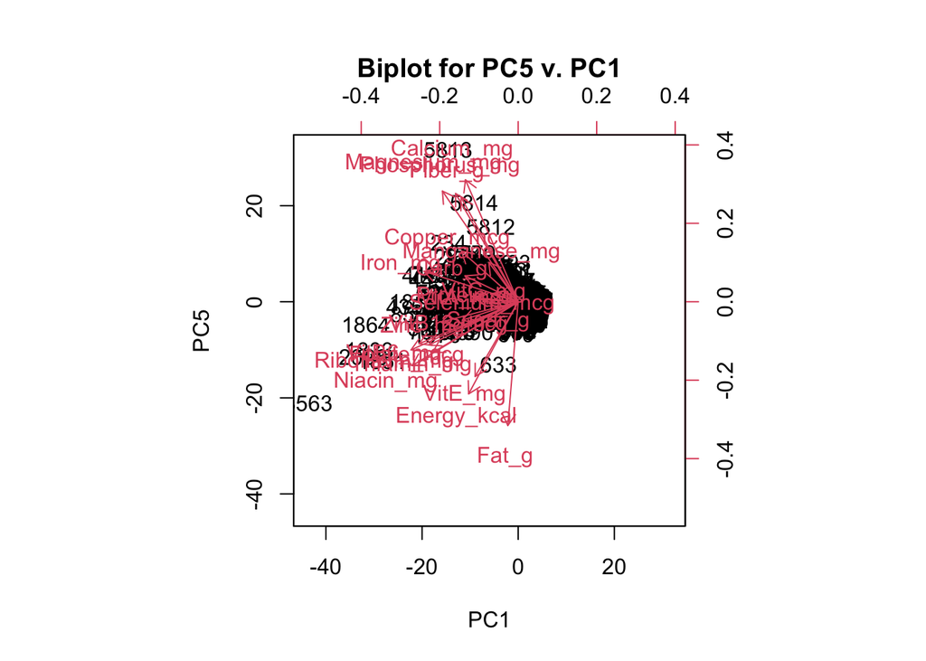

```r
biplot(nnpcomp, c(1,5), scale=0, main='Biplot for PC5 v. PC1')
```

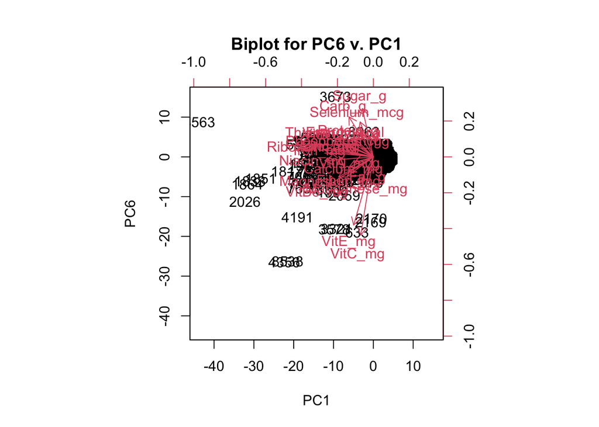

```r
biplot(nnpcomp, c(1,6), scale=0, main='Biplot for PC6 v. PC1')
```

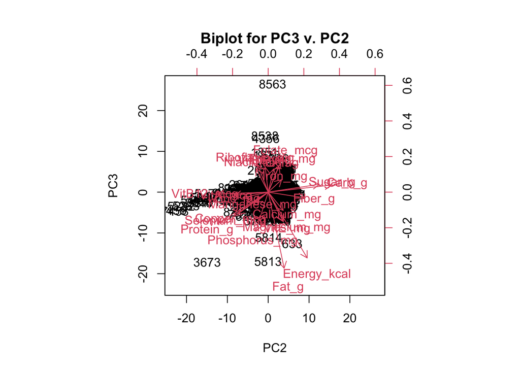

```r
biplot(nnpcomp, c(2,3), scale=0, main='Biplot for PC3 v. PC2')
```

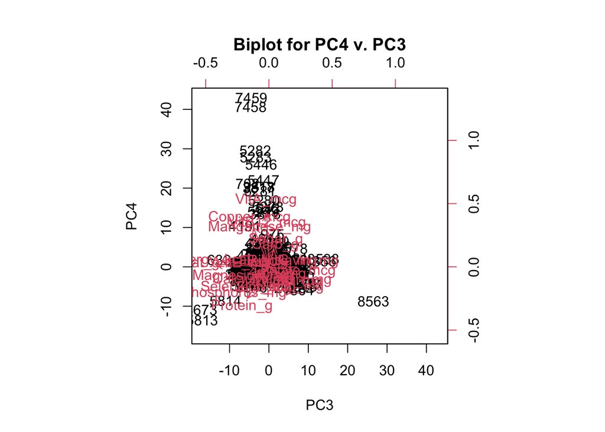

```r
biplot(nnpcomp, c(3,4), scale=0, main='Biplot for PC4 v. PC3')
```

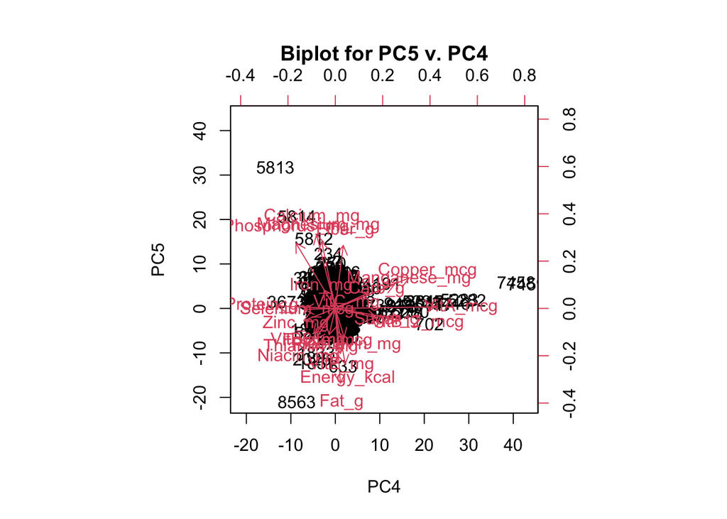

```r
biplot(nnpcomp, c(4,5), scale=0, main='Biplot for PC5 v. PC4')
```

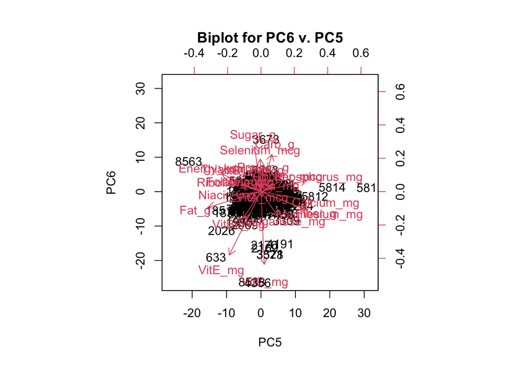

```r
biplot(nnpcomp, c(5,6), scale=0, main='Biplot for PC6 v. PC5')
```

### Question 8

**PVE**  
Does the plots show that `PC1` capture much more variance than `PC2`? `PC6`? (Of course we can confirm these with the PVE plot and calculations if we like. It is not required in this hw here.)

Yes, PC1 capture more of the variance than PC2 and PC6. This can be determined by the large length of the x axis that the PC1 is on. The variance decrease with each subsequent principle component.

### Question 9

**Interesting plots**  
If you look at the plot between `PC1` and `PC2`, it looks like a boomerang shape. (See image file in the hw zip.) Recall that `PC1` and `PC2` consists of rather different linear combinations of the original variables. And `PC1`-`PC2` have zero correlation. The chart shows us although `PC1` and `PC2` are overall un-correlated, when `PC1` change, there are only two different trends that `PC2` will change, as if there are only two types of nutrients in the 8000+ observations. Maybe these two kinds of food/items should be analyzed separately with two different models. These are some of the patterns and structures that PCA might be able to reveal.

At any rate, do you see other charts showing unexpected patterns?

Another unexpected pattern is the biplot between PC3 and PC4. This plot has a strange vertical upward pattern between PC3 and PC4.

## Optional

We will skip the model building using PCR here as it turns out not a productive exercise in that direction. While we are having this huge dataset, with 23 variables, this is actually a good candidate for performing the feature selection using leaps.

If you just look at the dataset and guess what are the good predictors to model Energy_kcal, what would you pick?

Now try run it by leaps regsubsets. What is the minimum number of predictors you will need, if you want to have a 90% $R^2$?